# Chapitre 5

## Le futur se trace

Manœuvrer dans le digital avec les cartes de Wardley

Le futur se trace

Manœuvrer dans le digital avec les cartes de Wardley

Olivier Wulveryck

# Chapitre 5 : La loi universelle de l’évolution technologique

Vous connaissez le terrain de jeu et ses forces (Partie I). Vous avez diagnostiqué votre organisation et inventorié vos capitaux (Partie II). Vous savez que le mouvement est inévitable, porté par la pression implacable de la concurrence. Mais une question demeure : ce mouvement obéit-il à des lois prévisibles, ou est-il un chaos qu’il faut subir ?

Dans cette troisième partie, nous allons dévoiler la « physique » du monde compétitif. Et cette physique commence par une loi fondamentale, aussi fiable que la gravité : **la Loi Universelle de l’Évolution Technologique**.

## Introduction : L’éclair de la découverte et le fleuve de l’évolution

Il existe une confusion fondamentale dans l’esprit de nombreux observateurs, une erreur de perspective qui brouille la lecture du jeu technologique. Cette erreur consiste à confondre l’événement de la **découverte** avec le processus de l’**évolution**.

La découverte est un phénomène soudain, incertain et parfois accidentel. C’est l’apparition de ce qui n’existait pas : la maîtrise du feu, l’invention du premier transistor, la création du premier réseau de neurones. C’est l’éclair dans la nuit, imprévisible et discontinu. Si la stratégie se résumait à prédire ces éclairs, elle serait un art divinatoire voué à l’échec.

Mais la technologie ne s’arrête pas à son apparition. Dès l’instant où une découverte se révèle utile, elle est happée par une seconde force, bien plus puissante et surtout **prévisible** : l’évolution.

Cette prévisibilité n’a rien de magique. Elle est la conséquence directe des règles du jeu que nous avons posées au **Chapitre 1**. Dans une économie de marché régie par l’offre et la demande, toute position statique est une anomalie temporaire. Dès qu’une valeur est créée, la concurrence vient mécaniquement l’attaquer pour la copier ou la dépasser.

C’est cette mécanique de marché qui rend le mouvement inévitable et engendre, par conséquent, l’effet de la Reine Rouge. Ce n’est pas une course que l’on choisit, mais une trajectoire imposée par la structure même de la compétition : si la demande existe, l’offre évoluera pour la satisfaire, avec ou sans vous.

Contrairement à la découverte qui est une rupture, l’évolution est une continuité. C’est la recherche inlassable de l’amélioration de l’existant, une mise en musique de l’innovation. C’est le mouvement inexorable qui transforme, jour après jour, l’exceptionnel en standard, **l’incertain en prévisible** (faisant écho à notre boussole du **Chapitre 2**), et le coûteux en accessible.

Gardons à l’esprit l’adage du statisticien George Box[^1] : *« Tous les modèles sont faux, mais certains sont utiles. »* Celui que nous allons explorer, issu des travaux de Simon Wardley[^2], se révélera particulièrement utile dans notre quête stratégique.

Ce méta-modèle unifie la lecture de votre organisation. Plutôt que de traiter séparément chaque type d’actif inventorié au **Chapitre 4** (en ayant une grille d’analyse pour la technologie, une autre pour les pratiques et une troisième pour les données), nous vous proposons ici une approche universelle.

C’est un **méta-modèle**. Il décrit la mécanique fondamentale de *comment* tout capital évolue sous la pression du marché, quelle que soit sa nature. Si le vocabulaire spécifique s’adapte pour décrire *ce qui* évolue (on ne parle pas de la même façon de la maturation du code source et de celle du savoir), la loi du mouvement, elle, reste immuable pour l’ensemble de votre véhicule.

Cependant, ne nous méprenons pas sur l’exercice. **Anticiper une trajectoire, ce n’est pas prédire l’avenir.** Nous ne lisons pas dans une boule de cristal, nous faisons de la balistique. Nous projetons le chemin naturel d’un actif, tout en sachant que cette course ne se fait pas dans le vide. Cette trajectoire subira les frictions du marché, les collisions avec vos autres capitaux et l’influence de forces qui nous dépassent.

Cette distinction est cruciale pour réconcilier ce chapitre avec les enseignements du **Chapitre 2**. Là-bas, nous avons appris avec Stacey et Cynefin que le monde est fondamentalement incertain, que le complexe résiste à la prédiction. Comment, dès lors, oser parler ici de « loi prévisible » ? La réponse tient en une phrase : **la trajectoire est prévisible, mais le rythme reste incertain.**

Nous savons *où* va une technologie utile : de l’incertitude vers la certitude, de la rareté vers l’ubiquité. C’est une direction, pas un horaire de train. Nous ne pouvons pas prédire *quand* l’IA quantique basculera en Phase II, ni combien d’années le Cloud mettra à devenir aussi invisible que l’électricité. Ces échéances dépendent de facteurs imprévisibles : une découverte fortuite, un changement réglementaire, une crise économique, l’arrivée d’un acteur disruptif.

C’est précisément cette distinction qui rend le modèle utile sans le rendre dangereux. Il ne vous promet pas de timing, mais il vous offre une boussole directionnelle. Vous savez dans quelle direction couler votre énergie, même si vous ne savez pas exactement quand vous arriverez.

C’est aussi là tout l’enjeu pour l’architecte du mouvement : comprendre cette trajectoire théorique pour lire la situation réelle, et acquérir enfin le pouvoir non seulement de l’anticiper, mais de la **corriger**.

Mais avant d’agir sur la course, comprenons le moteur de la machine. Pourquoi est-il impossible pour une technologie utile de rester immobile ? Quelle est cette mécanique implacable qui nous force à améliorer sans cesse l’existant ?

## Le moteur du mouvement – la danse de l’offre et de la demande

### Le mythe du temps (l’erreur de perspective)

Il existe une idée reçue tenace dans le monde des affaires : la croyance que la technologie mûrit naturellement avec le temps, à la manière d’un grand vin qui se bonifiera paisiblement dans l’obscurité d’une cave.

Cette intuition repose sur une erreur d’attribution. Nous confondons **l’agent** (ce qui produit le changement) avec **la scène** (le cadre dans lequel le changement se produit). Le temps n’est pas l’agent de la maturation technologique, c’est simplement la scène nécessaire pour qu’un autre phénomène opère.

Prenons l’analogie du vin : ce qui le fait mûrir, ce n’est pas « le temps » en soi, c’est un processus chimique (oxydation, transformation des tanins) qui *nécessite* du temps pour se dérouler. Le temps est le conteneur, pas le moteur. Si vous remplacez le vin par de l’eau dans la même cave pendant dix ans, l’eau ne « mûrira » pas, car il n’y a pas de processus interne.

Prenons maintenant le fromage. Un camembert mûrit en trois semaines dans des conditions optimales de température et d’humidité. Mais congelez-le, et il restera quasi-inerte pendant des mois. Laissez-le à température ambiante sans contrôle, et il pourrira en cinq jours. **Le temps écoulé (3 semaines, 5 jours, 6 mois) ne vous dit rien sur l’état du fromage si vous ne connaissez pas l’environnement.**

Pour la technologie, c’est exactement pareil. Une ligne de code écrite aujourd’hui et isolée sur un serveur pendant dix ans ne deviendra pas plus performante. Elle ne se débuggera pas toute seule. Au contraire, elle deviendra obsolète, une dette technique, une faille de sécurité. Inversement, une technologie plongée dans un environnement de compétition féroce (pensez aux navigateurs web entre 2008 et 2015) peut passer de « bricolage » à « commodité mondiale » en cinq ans. La même technologie, protégée par un monopole ou un marché régulé, peut stagner pendant vingt ans sans évoluer d’un pouce.

**Dire qu’une technologie « a 10 ans donc elle est mature » n’a aucun sens si vous ne savez pas quelle pression elle a subie.** Le temps est nécessaire non pas parce qu’il agit, mais parce qu’il faut une durée pour que s’accumulent les effets de la **pression compétitive** : la force constante exercée par l’offre (qui innove pour capturer le marché) et par la demande (qui exige toujours mieux). Ce qui transforme un bricolage de garage en une commodité mondiale, ce ne sont pas les années écoulées, ce sont les milliers d’itérations, d’échecs, de critiques clients, de tentatives concurrentes qui se sont produits *pendant* cette période.

Les « Actifs » que nous avons inventoriés au chapitre précédent (votre code, vos processus, vos infrastructures) ont effectivement une trajectoire d’évolution. Mais cette trajectoire n’est pas une horloge interne qui tic-taque toute seule. Elle est **forcée** de l’extérieur par cette pression constante.

### Le moteur à deux temps (la co-évolution)

Si le temps n’est que la scène, quel est le moteur ? C’est un mécanisme de **co-évolution**. Et nous n’utilisons pas ce terme ici comme une simple métaphore littéraire, mais dans son sens biologique strict : une causalité réciproque où deux entités se modifient l’une l’autre sous la pression de la sélection.

Pensez à la relation entre le guépard et la gazelle. Le guépard évolue pour courir plus vite afin de manger ; la gazelle évolue pour courir plus vite afin de ne pas être mangée. Ce n’est pas une action à sens unique, c’est une boucle de rétroaction où chaque adaptation de l’un force la mutation de l’autre.

Dans l’économie, cette danse se joue entre la **Technologie** (ce que nous construisons) et la **Pratique** (ce que nous faisons) :

D’un côté, l’**offre innove** : le fournisseur introduit une nouveauté pour capturer le marché (le guépard accélère). De l’autre, la **demande mute** : en adoptant cette technologie, le client change de comportement. Il ne fait pas qu’acheter un produit, il développe de nouvelles habitudes, de nouvelles attentes.

C’est ici que le piège se referme. Le client de 2025 est biologiquement le même que celui de 1950, mais économiquement, c’est une espèce différente. L’invention du smartphone n’a pas seulement répondu à un besoin, elle a *muté* le client en créant chez lui une addiction à l’instantanéité et à l’accès permanent. Cette nouvelle « pratique » rend soudainement l’ancien standard (le téléphone fixe, le courrier papier) intolérable. Le client a évolué, forçant l’offre à s’adapter à nouveau pour survivre.

Le cycle se répète indéfiniment. L’innovation d’un fournisseur éduque le client, qui devient plus exigeant, ce qui rend l’ancien standard obsolète et force les fournisseurs à innover à nouveau pour survivre.

Ce n’est pas un échange commercial apaisé, c’est un **conflit créateur** permanent. Et le carburant de ce moteur, c’est l’insatisfaction perpétuelle du client. La gratitude pour une innovation est éphémère : ce qui est magique aujourd’hui devient normal demain, puis insuffisant après-demain.

### L’impossibilité du statu quo

C’est précisément parce que cette co-évolution est biologique et comportementale qu’elle est inarrêtable. Cela nous ramène à la « Reine Rouge » de Lewis Carroll, évoquée au Chapitre 1 : *« Il faut courir de toute la vitesse de ses jambes pour simplement demeurer là où l’on est. »*

En biologie évolutive, l’hypothèse de la Reine Rouge sert à expliquer pourquoi les espèces doivent constamment évoluer juste pour ne pas s’éteindre, même dans un environnement stable. Dans le business, c’est la même loi. Puisque le couple « Technologie-Pratique » tourne en permanence, le sol sous vos pieds est un tapis roulant.

L’immobilité est une illusion d’optique. Dans un système où le client mute et où le standard du marché avance, décider de ne pas bouger (le statu quo) revient mathématiquement à reculer.

Certains acteurs puissants tentent parfois de gripper ce mécanisme. Les monopoles, comme les barons des chemins de fer ou certains géants de la tech, ont cru pouvoir figer le marché pour extraire une rente. Mais la co-évolution est plus forte que n’importe quel monopole. Lorsque l’offre refuse d’avancer, la pression de la demande s’accumule comme l’eau derrière un barrage, jusqu’à ce que le marché contourne l’obstacle (à la manière de l’eau qui trouve toujours son chemin), rendant le monopole non pas vaincu, mais *inutile*.

L’évolution n’est donc pas une option stratégique. C’est une gravité. Vous ne choisissez pas si la technologie va évoluer, vous choisissez seulement si vous évoluez avec elle ou si vous devenez la gazelle qui a cessé de courir.

## Modéliser l’évolution – la double hélice

Nous savons désormais que le mouvement est inévitable. La co-évolution entre l’offre et la demande, alimentée par la pression compétitive, force chaque technologie, chaque pratique, chaque actif à évoluer. Mais savoir *que* ça bouge ne suffit pas. Pour naviguer, il faut savoir **où** nous en sommes sur ce chemin, et **vers où** nous allons.

Le problème, c’est que l’offre et la demande sont **dépendantes du contexte**. Ce qui se vend aujourd’hui dans le cloud computing n’a rien à voir avec ce qui se vendait dans les chemins de fer au XIXe siècle. Les acteurs changent, les technologies changent, les marchés changent. Comment, dès lors, construire un modèle intemporel de l’évolution qui transcende ces contingences ?

La réponse réside dans une observation clé : bien que l’offre et la demande soient spécifiques à chaque contexte, **elles répondent à des régularités structurelles**. Elles obéissent à des mécanismes récurrents que l’on peut isoler et modéliser.

Simon Wardley a posé l’hypothèse suivante : pour construire un axe d’évolution intemporel, il faut identifier des dimensions qui, bien qu’influencées par l’offre et la demande, ne dépendent pas du contexte particulier. Il en a identifié deux :

1. **Du côté de la demande** : l’**ubiquité** (ou omniprésence sur le marché). Cette dimension mesure à quel point une solution s’est propagée dans le marché, un phénomène que la théorie de la **diffusion de l’innovation** d’Everett Rogers[^3] permet de comprendre et de prédire.
2. **Du côté de l’offre** : la **certitude**. Cette dimension, que nous avons présentée au **Chapitre 2**, mesure à quel point nous savons *comment* construire et opérer une solution. Elle capture le degré de maîtrise collective d’une technologie.

Wardley a ensuite validé empiriquement que l’évolution pouvait être définie comme **la relation entre ces deux dimensions** : l’omniprésence sur le marché (poussée par la diffusion de l’innovation) et la certitude (au sens de Stacey). En analysant des centaines de composants technologiques sur plusieurs décennies, il a constaté que ces deux dimensions progressent ensemble de manière structurée, **dessinant une trajectoire prévisible, bien que le rythme reste incertain.**

Ceci a abouti au modèle présenté dans ce chapitre. Il s’est révélé **très utile** dans les contextes où il a été appliqué. Aucun contre-exemple majeur n’a été documenté, bien que sa validation reste empirique plutôt qu’expérimentale. Sa cohérence interne en fait un outil de navigation stratégique fiable, sans prétendre au statut de loi scientifique universelle. Mais pour comprendre sa puissance, il faut d’abord comprendre ses fondations.

### La dimension de l’ubiquité : le regard de Rogers

Le premier regard est celui d’**Everett Rogers** et de sa théorie de la diffusion de l’innovation (1962). Rogers nous enseigne comment la demande se propage dans un marché. Son modèle célèbre identifie cinq catégories d’adopteurs, distribuées selon une courbe en cloche :

- **Les innovateurs** (2,5% du marché) : audacieux, prêts à payer une prime et à accepter les imperfections pour toucher l’avenir.
- **Les adopteurs précoces** (13,5%) : visionnaires qui cherchent un avantage compétitif.
- **La majorité précoce** (34%) : pragmatiques qui attendent que la technologie soit « prouvée ».
- **La majorité tardive** (34%) : sceptiques qui adoptent sous pression sociale ou économique.
- **Les retardataires** (16%) : résistants qui n’adoptent que lorsqu’il n’y a plus d’alternative.

Prenons l’exemple du smartphone pour illustrer ce parcours. En 2007, lorsque l’iPhone est lancé, seuls quelques enthousiastes technophiles se précipitent. Ce sont les innovateurs. Puis viennent les adopteurs précoces (ces cadres dynamiques qui veulent un avantage professionnel). L’adoption s’accélère ensuite massivement quand la majorité découvre que « tout le monde en a un », jusqu’à ce que même votre grand-mère possède un smartphone.

C’est la mesure de l’**ubiquité** : à quel point une technologie est-elle présente dans le monde ? Mais cette vision quantitative, aussi puissante soit-elle, ne suffit pas à piloter une stratégie. Savoir qu’une technologie est largement adoptée ne nous dit rien sur son degré de maîtrise, de standardisation, ou de stabilité. Une technologie peut être omniprésente et pourtant encore chaotique (pensez au JavaScript des années 2000, omniprésent car livré avec tous les navigateurs, mais encore chaotique du fait des divergences d’implémentation entre les moteurs). Il nous manque une seconde dimension.

### La dimension de la certitude : le regard de Stacey

C’est ici qu’intervient le second regard, celui de la **certitude**, emprunté aux travaux de **Ralph Stacey**[^4] dont nous avons parlé précédemment dans ce livre.

Au début de l’histoire d’une technologie, nous sommes dans l’incertitude totale : nous ne savons pas ce qui va marcher, ni comment le construire. C’est le domaine de l’exploration et de l’expérimentation.

Reprenons l’exemple du développement web. Dans les années 1990, créer un site web était un acte de pionnier. Fallait-il utiliser des tables HTML ou des frames ? Quel langage côté serveur ? Perl, PHP, ou ASP ? Il n’y avait pas de bonnes réponses, seulement des paris et des échecs instructifs. Chaque développeur réinventait la roue, chaque projet était une aventure unique.

À mesure que la **pression compétitive** (souvenez-vous de la Partie 1) affine les solutions, nous apprenons collectivement. Le savoir se décante. Les échecs collectifs éliminent les impasses (adieu les frames et Flash). Les succès se transforment en standards (bonjour HTML5, CSS3, et JavaScript). Nous migrons progressivement vers la **certitude** : ce qui était autrefois de l’alchimie devient de l’ingénierie. Ce qui nécessitait des experts devient accessible à des techniciens. Ce qui était artisanal devient industriel.

### La synthèse : l’axe d’évolution (le modèle de Wardley)

L’intuition géniale de Wardley a été de comprendre que ces deux dimensions (l’**ubiquité** de Rogers et la **certitude** de Stacey) ne sont pas indépendantes. Elles sont **colinéaires** : elles progressent ensemble, de manière mécanique, sous la pression de la co-évolution que nous avons décrite.

Pourquoi ? Parce que :

La boucle fonctionne dans les deux sens. L’**ubiquité force la certitude** : plus une technologie est adoptée, plus il y a de tentatives, d’échecs, de retours d’expérience, et le savoir s’accumule. En retour, la **certitude accélère l’ubiquité** : plus une technologie est maîtrisée et standardisée, moins elle est risquée à adopter, et les barrières à l’entrée s’effondrent.

C’est cette boucle de rétroaction qui dessine la **courbe en S** caractéristique de l’évolution :

Au départ, l’adoption est lente (peu d’innovateurs) et l’incertitude maximale (personne ne sait comment faire). Au milieu, à mesure que le problème est mieux compris et que les solutions se stabilisent, l’adoption s’accélère brutalement : c’est la majorité qui déferle. À la fin, la courbe plafonne quand la technologie devient universelle et parfaitement maîtrisée.

**Wardley a construit ce modèle empiriquement** en analysant des centaines de composants technologiques (du calcul distribué aux bases de données, des langages de programmation aux infrastructures cloud) et en constatant que tous suivaient ce même parcours. Ce n’est pas une théorie spéculative, c’est un pattern récurrent observé empiriquement, une régularité du système économico-technologique.

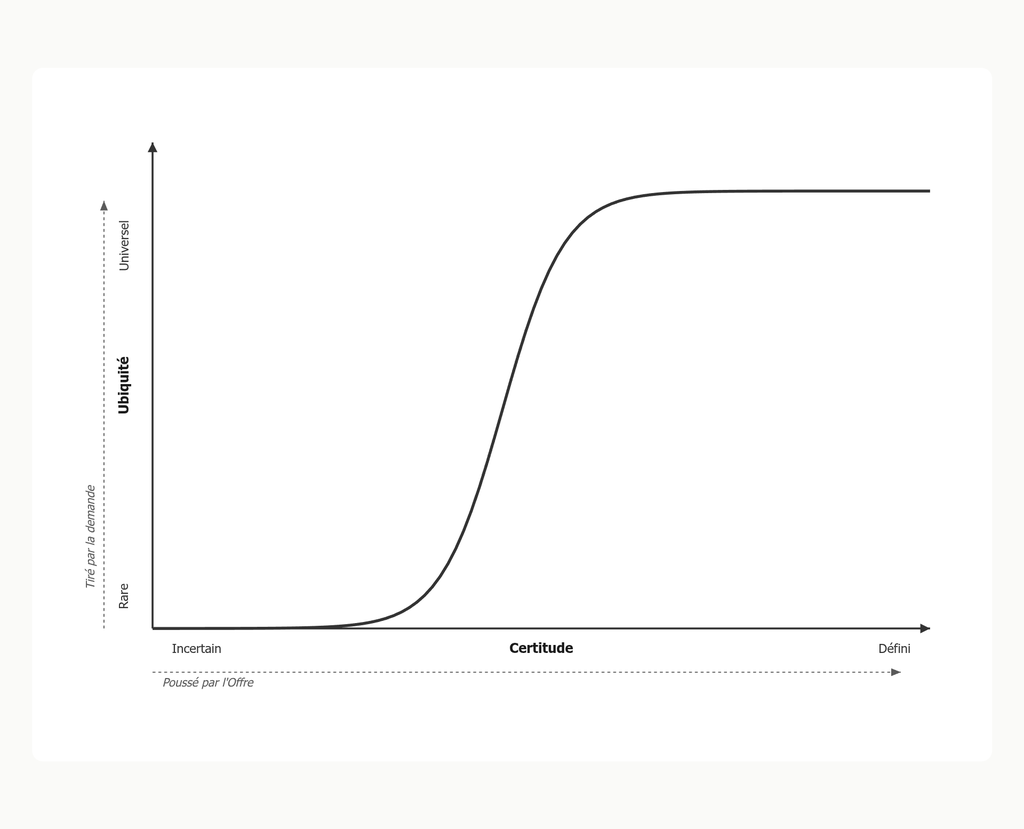

L’axe horizontal de la Carte de Wardley est tout simplement cette courbe en S « aplatie ». Il représente le voyage inévitable de la découverte hasardeuse vers la standardisation industrielle. Et c’est sur cet axe que nous allons maintenant positionner les quatre phases universelles de l’évolution.

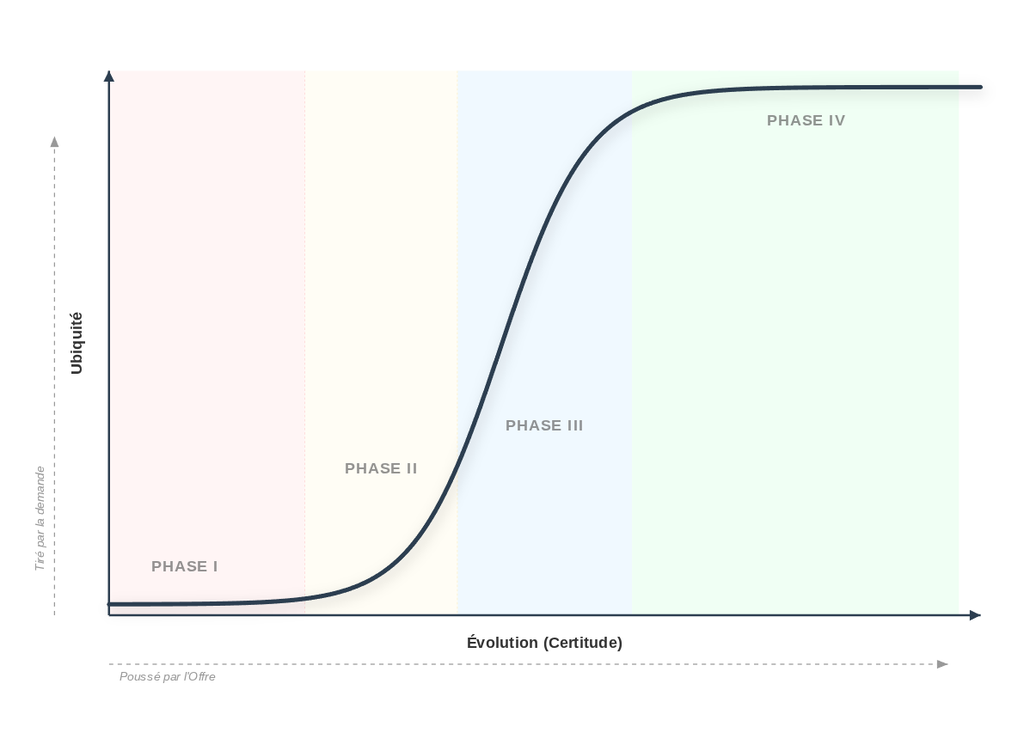

### L’architecture du voyage : une métamorphose en quatre actes

Regarder l’axe d’évolution, ce n’est pas simplement observer une courbe de croissance ou de parts de marché. C’est assister à une série de métamorphoses radicales. Un actif qui traverse ce graphe ne fait pas que « grandir » ; il change de nature profonde. La manière dont on le construit, dont on le finance, et même dont on tolère son échec, change du tout au tout.

Pour comprendre ce voyage, imaginons-le comme une traversée de quatre mondes distincts, chacun régi par ses propres lois.

**Tout commence dans le monde de l’Inconnu et de la Découverte.** C’est le territoire des explorateurs. Ici, la technologie est une promesse, un frisson, parfois une magie. On ne sait pas encore vraiment à quoi elle servira, ni si elle sera rentable, mais on sent son potentiel de rupture. Pensez à l’**Informatique Quantique** aujourd’hui. C’est un domaine fascinant, peuplé de physiciens et de prototypes instables. Si vous investissez ici, vous ne cherchez pas l’efficacité, vous jouez au casino de l’avenir. L’échec n’est pas seulement toléré, il est la norme : chaque erreur est une leçon qui réduit l’incertitude. C’est un monde guidé par l’intuition et le pari, où l’avantage concurrentiel réside dans le simple fait de savoir faire ce que les autres jugent impossible.

**Si la technologie survit, elle glisse vers le monde de l’Artisanat et des Experts.** La magie s’est dissipée pour laisser place à l’ingénierie, mais une ingénierie d’élite. Nous savons que « ça marche », mais nous ne savons pas encore le produire en masse ou le standardiser. Chaque implémentation est unique, taillée sur mesure pour un besoin précis. Souvenez-vous des **premiers sites web d’entreprise** vers la fin des années 90. Il n’y avait pas de standards, pas de plateformes prêtes à l’emploi. Chaque entreprise devait embaucher des « webmasters » coûteux pour coder à la main, ligne par ligne. C’était lourd, cher, et difficile à maintenir. Ici, la valeur réside dans la compétence humaine de ceux qui fabriquent. On cherche le retour sur investissement, mais on apprend encore en marchant, en construisant nos propres outils pour nos propres besoins.

**Le basculement s’opère ensuite vers le monde de la Standardisation et de la Performance.** C’est le moment critique où la technologie se fige suffisamment pour être emballée, distribuée et comparée. L’artisanat laisse place à l’industrie. La demande explose et la compétition change de visage : ce n’est plus une course à « qui sait le faire », mais une guerre de fonctionnalités pour savoir « qui le fait le mieux ». Regardez la bataille actuelle des **Grands Modèles de Langage (LLM)**. Nous ne sommes plus dans la découverte théorique, ni dans le bricolage artisanal. C’est une guerre industrielle où l’on compare la vitesse, la taille du contexte, la précision. Le client a le choix, il compare les offres concurrentes et devient exigeant. L’échec, qui était une source d’apprentissage au début, devient ici un défaut de qualité. On ne veut plus apprendre comment ça marche, on veut l’utiliser pour gagner.

**Enfin, le voyage s’achève dans le monde de l’Ubiquité et de l’Invisible.** C’est le stade ultime. La technologie a gagné : elle est devenue si performante, si fiable et si omniprésente qu’elle a disparu de nos consciences. Elle ne se vend plus par ses caractéristiques « sexy », mais au volume, au compteur, comme une ressource élémentaire. L’exemple parfait est l’**Électricité** ou le **Cloud Computing** moderne. Personne ne demande à son fournisseur d’énergie si ses électrons sont plus innovants que ceux du voisin. On se branche, c’est tout. C’est un monde d’utilité pure, de volume massif et de marges faibles. Ici, l’innovation ne consiste plus à améliorer la chose elle-même, mais à construire *par-dessus* elle. La seule fois où l’on remarque une technologie à ce stade, c’est quand elle tombe en panne : ce qui était une aventure au début est devenu une exigence silencieuse.

Pourquoi cette narration est-elle vitale pour le stratège ? Parce que **chaque monde exige un chef différent.** Vous ne pouvez pas gérer l’exploration quantique avec les méthodes rigides d’une centrale électrique, sous peine d’étouffer toute découverte. Inversement, gérer votre infrastructure critique avec l’esprit *fail fast* et l’improvisation du début est une invitation au désastre.

L’évolution n’est donc pas juste une théorie académique ; c’est le guide qui vous dicte comment agir, qui embaucher et comment mesurer le succès à chaque étape du chemin.

**Note méthodologique :** Wardley a construit ce modèle par **induction empirique** (observation de patterns récurrents) et non par déduction théorique. C’est ce qui en fait la force : il n’a pas plaqué une théorie sur le réel, il a extrait la théorie du réel.

Cependant, soyons clairs sur le périmètre de validité de ce modèle. Il décrit une mécanique observée dans un contexte bien précis : **une économie de marché capitaliste et concurrentielle**, telle que nous l’avons décrite au **Chapitre 1**. C’est la pression de la concurrence (l’offre qui cherche à capturer la demande, la demande qui exige toujours mieux) qui alimente le moteur de l’évolution.

Que se passerait-il dans un contexte radicalement différent ? Dans une économie planifiée, un monopole d’État absolu, ou un marché sans concurrence ? Nous n’avons tout simplement pas de données pour l’affirmer. Le modèle n’a pas été testé dans ces conditions, et il serait présomptueux de prétendre qu’il s’y appliquerait de la même manière.

Rappelons l’adage de George Box : *« Tous les modèles sont faux, mais certains sont utiles. »* Ce modèle ne prétend pas être une vérité scientifique universelle. Il n’a pas la rigueur d’une loi de physique. Mais dans le contexte économique qui est le nôtre (le capitalisme concurrentiel du XXIe siècle), il s’est révélé **redoutablement utile**. Son pouvoir prédictif (anticiper les mouvements du marché) a été démontré dans de nombreux contextes industriels. C’est cette utilité pragmatique, et non une prétention à la vérité absolue, qui justifie son usage.

## Les quatre phases universelles – au-delà des étiquettes

Pour rendre ce concept viscéral, prenons l’exemple de l’Intelligence Artificielle, qui traverse ce cycle sous nos yeux. Tout commence par la **Genèse**. C’est le temps du Perceptron et des premiers réseaux de neurones. L’ambiance est celle du laboratoire de l’alchimiste : on s’émerveille qu’une machine puisse apprendre un concept simple, l’échec est fréquent, et la valeur réside dans la promesse future. Puis vient la phase du **Sur Mesure**. C’est l’ère du Deep Learning artisanal, où des experts codent manuellement des couches de convolution. On consolide le savoir, on réussit à reproduire le miracle, mais cela reste un artisanat d’élite, coûteux et lent.

Le basculement s’opère ensuite vers la phase de **Produit**. Des outils comme TensorFlow ou PyTorch apparaissent. L’IA devient accessible, les fonctionnalités se standardisent, la compétition fait rage sur la performance et la facilité d’usage. Enfin, nous entrons dans la phase de **Commodité**. C’est l’IA générative consommée via une API. On ne se soucie plus des tenseurs ou des mathématiques sous-jacentes ; on se branche sur l’intelligence comme on se branche sur le réseau électrique. La technologie est devenue invisible, standardisée et ubiquitaire.

Mais la plus grande erreur serait de croire que ces étiquettes ne s’appliquent qu’aux logiciels ou au matériel. Ce cycle en quatre temps est une loi universelle qui s’applique à tous les capitaux de l’entreprise. Les **activités** passent de la Genèse à la Commodité. Les **pratiques** de travail évoluent de « Nouvelles » (inédites et risquées) à « Bonnes », puis à « Meilleures pratiques » (standards industriels). Même les **données** suivent ce chemin, passant d’un état non-modélisé et chaotique à un état structuré et universel. Pour le stratège, la leçon est cruciale : ne vous laissez pas piéger par les noms. Regardez le comportement de l’actif. S’il est expérimental et changeant, il est en phase I. S’il est stable, standard et volumique, il est en phase IV, qu’il s’agisse de code, de méthode agile ou de base de données.

### L’évolution des pratiques : du pionnier au standard industriel

Nous avons illustré l’évolution avec le code et l’infrastructure. Mais souvenez-vous de notre inventaire du **Chapitre 4** : vos capitaux ne se limitent pas à la technologie. Vos **pratiques de travail** (la manière dont vous organisez, décidez et collaborez) suivent exactement le même cycle.

Prenons l’exemple de l’**Agilité** dans le développement logiciel. Dans les années 1990, des équipes isolées expérimentent des approches radicalement différentes du cycle en V : Kent Beck invente l’Extreme Programming chez Chrysler[^5], Jeff Sutherland crée Scrum[^6]. Ce sont des pratiques de Genèse, marginales et risquées. Le Manifeste Agile[^7] (2001) cristallise ces expériences et fait basculer l’Agilité en Phase II : chaque implémentation reste un artisanat sur mesure, porté par des consultants experts, mais « être Agile » devient un avantage concurrentiel. Dans les années 2010, la Phase III s’installe : certifications (Scrum Master, SAFe), outils industriels (Jira, Azure DevOps), adoption massive. L’Agile n’est plus un avantage, c’est un prérequis. Aujourd’hui, Phase IV : demander à une équipe si elle est « Agile » revient à demander si elle utilise l’électricité. La différenciation ne vient plus de *faire* de l’Agile, mais de *ce que l’on construit avec*.

La leçon est limpide : **gérer une pratique émergente (Phase I) comme un standard (Phase IV) tue l’innovation**. Imposer des certifications rigides à une équipe qui explore, c’est étouffer la découverte. Inversement, traiter une pratique mature comme si elle était encore expérimentale (en réinventant Scrum à chaque projet) est un gaspillage de temps.

### L’évolution des données : du chaos au standard universel

Le même cycle s’applique à votre **Capital de Données**. En Phase I, c’est le Far West : fichiers Excel sur les postes de travail, exports CSV envoyés par email, chaque département son propre « système » (généralement le disque dur d’un collaborateur clé). En Phase II, l’organisation rationalise en silos : le Marketing a son CRM, la Finance son ERP, la Production son MES (Manufacturing Execution System), mais croiser les informations nécessite des développements sur mesure. En Phase III, le Data Warehouse émerge : des plateformes (Snowflake, Databricks) centralisent et normalisent les données, les « Data Engineers » deviennent une profession reconnue. En Phase IV, certaines données deviennent des standards universels (codes postaux, codes ISO, formats de dates) que personne ne réinvente, et le mouvement *Data as a Product* pousse cette logique plus loin : chaque jeu de données interne est traité comme un produit avec une interface stable et un contrat de service.

L’erreur stratégique classique ? **Traiter des données Phase I comme si elles étaient Phase IV**. Exiger des KPI temps réel sur des données dont personne ne comprend la signification, c’est construire un château sur du sable. Inversement, maintenir des processus manuels pour des données qui devraient être des flux automatisés standardisés, c’est gaspiller du capital humain précieux.

### Le piège du mauvais diagnostic : l’erreur de phase

Le danger le plus insidieux de cette loi universelle n’est pas de l’ignorer, c’est de mal l’appliquer. Diagnostiquer la mauvaise phase conduit à des erreurs stratégiques coûteuses.

**Erreur Type 1 : Traiter une Phase I comme une Phase IV**

C’est l’erreur de l’organisation bureaucratique face à l’innovation. Elle voit émerger une nouvelle technologie (l’IA générative en 2023, par exemple) et applique immédiatement ses processus industriels : appels d’offres, comités de sélection, plans de déploiement à trois ans, ROI garantis.

Mais en Phase I, personne ne sait encore ce qui va marcher. Exiger des certitudes, c’est tuer l’exploration. Les équipes, incapables de fournir les garanties demandées, abandonnent ou mentent sur leurs projections. Le projet est soit enterré, soit lancé sur des fondations de sable.

**L’antidote** : En Phase I, adoptez l’approche F.I.R.E. que nous avons vue au **Chapitre 3**. Petits budgets, itérations rapides, droit à l’échec. Ne demandez pas un business case, demandez une hypothèse à tester.

**Erreur Type 2 : Traiter une Phase IV comme une Phase I**

C’est l’erreur du syndrome *Not Invented Here* que nous avons diagnostiqué au **Chapitre 3**. L’organisation décide de reconstruire en interne ce qui existe en standard sur le marché, persuadée que ses besoins sont « uniques ».

Souvenez-vous du grille-pain de Thomas Thwaites[^8]. Reconstruire une base de données relationnelle, un système de messagerie, ou un framework web en 2025, c’est exactement la même absurdité. Vous mobilisez vos meilleurs talents sur des problèmes que l’écosystème a résolus depuis des années.

**L’antidote** : En Phase IV, achetez, louez, standardisez. Réservez votre énergie créative pour les phases où elle crée réellement de la valeur.

**Erreur Type 3 : Ignorer la Transition Phase II → Phase III**

C’est le moment le plus dangereux du cycle. Votre organisation a développé une compétence rare en Phase II. Vos experts sont fiers de leur artisanat. Ils ont construit quelque chose d’unique. Mais le marché évolue, et des produits standardisés commencent à apparaître.

Le piège ? L’attachement émotionnel. Vos experts résistent à l’adoption des produits du marché parce que cela dévalue leur expertise. Ils trouvent toujours une raison pour laquelle « le produit X ne répond pas à nos besoins ». En réalité, ils protègent leur territoire.

**L’antidote** : Anticipez cette résistance. Au **Chapitre 3**, nous avons vu que l’inertie des compétences est l’une des plus violentes. Préparez la reconversion de vos experts *avant* que leur domaine ne bascule en Phase III. Offrez-leur un nouveau territoire d’exploration plutôt que de les laisser défendre un château qui s’effondre.

## Le paradoxe de la valeur – de la pépite au socle

Si une technologie finit inévitablement par devenir banale et invisible, pourquoi nous battons-nous pour l’obtenir ? Il existe un malentendu profond sur la notion de valeur dans l’évolution technologique. Intuitivement, nous associons la valeur à ce qui est rare et unique. C’est la **valeur de différenciation**. En phase de Genèse ou de Sur Mesure, posséder une technologie que personne d’autre n’a offre un avantage compétitif majeur et permet des marges élevées. Mais à mesure que l’actif évolue vers la droite, cette valeur s’effondre. L’ubiquité tue la rareté. Cependant, une autre forme de valeur prend le relais, souvent méprisée à tort : la **valeur d’utilité**.

Prenons l’analogie de l’électricité. Personne ne s’extasie aujourd’hui devant une prise murale. Elle ne confère aucun avantage concurrentiel direct ; l’utiliser ne vous rend pas meilleur que votre voisin. Pourtant, essayez de faire tourner votre entreprise sans elle. La valeur d’utilité est binaire : sans elle, rien ne fonctionne. Plus une technologie devient une commodité, plus elle devient vitale pour la survie de l’organisation, devenant le socle indispensable sur lequel se construisent les innovations futures. L’erreur stratégique mortelle consiste à traiter ces commodités comme des actifs différenciants, en dépensant des fortunes pour « réinventer la roue », ou à l’inverse, à les négliger parce qu’elles ne « brillent » plus, mettant en péril toute la structure.

### La phase dicte la stratégie : *build vs buy* revisité

Au **Chapitre 4**, nous avons exploré les cas de Dell/Asus et de Dropbox pour illustrer le dilemme éternel : faut-il construire ou acheter ? Nous pouvons maintenant reformuler cette question avec une précision chirurgicale grâce à notre compréhension de l’évolution.

**La règle est simple : la phase détermine la stratégie.**

| Phase | Stratégie dominante | Justification |
| --- | --- | --- |
| **Genèse (I)** | **Build** — Explorer | Ce qui n’existe pas encore ne peut pas s’acheter. Vous devez créer. |
| **Sur Mesure (II)** | **Build** — Différencier | Votre artisanat est votre avantage. Les produits du marché ne répondent pas encore à vos besoins. |
| **Produit (III)** | **Buy ou Build** — Évaluer | Le marché propose des solutions. Comparez honnêtement : votre version interne est-elle vraiment meilleure ? |
| **Commodité (IV)** | **Buy** — Standardiser | Reconstruire une commodité est un gaspillage. Achetez, louez, branchez-vous. |

L’erreur de Dell était précisément un mauvais diagnostic de phase. Ils ont traité leur capacité intégrative (Phase II — Sur Mesure) comme une commodité externalisable (Phase IV). En sous-traitant à Asus, ils n’ont pas simplement réduit leurs coûts, ils ont abandonné leur avantage compétitif.

À l’inverse, Dropbox a su reconnaître que le stockage, initialement une commodité qu’ils achetaient à AWS, était devenu le cœur de leur proposition de valeur à l’échelle où ils opéraient. Ils ont fait le chemin inverse : ramener en interne (Build) ce qui était auparavant loué (Buy), parce que leur contexte avait changé.

La leçon pour l’architecte du mouvement : **le diagnostic de phase n’est pas un exercice théorique, c’est le fondement de toutes vos décisions d’investissement**. Avant chaque projet, avant chaque budget, posez la question : « Dans quelle phase se trouve cet actif ? » La réponse dicte la méthode.

### Le paradoxe du succès : comment la réussite engendre l’immobilisme

Et c’est ici que se noue le drame stratégique le plus cruel. Plus un actif réussit, plus il devient difficile à abandonner. Le système de gestion sur mesure qui vous donnait un avantage il y a dix ans est devenu une prison : le marché l’a rattrapé, la maintenance est un gouffre, et les experts qui le maintiennent défendent leur territoire. C’est le **paradoxe du succès** : le système qui vous a fait gagner hier est celui qui vous empêche de gagner demain.

Ce que la loi de l’évolution nous révèle, c’est que **l’inertie n’est pas un accident**. Elle est une conséquence mécanique du succès. Chaque actif qui traverse le cycle accumule autour de lui une masse croissante : légère en Phase I, considérable en Phase III, et potentiellement allégée en Phase IV si vous avez fait le bon choix de standardisation. Cette accumulation rend le principe « No Core » (être prêt à tuer sa vache à lait) si difficile à appliquer : plus vous avez réussi, plus le changement est douloureux.

Face à la force de l’évolution se dresse donc cette force contraire. L’évolution vous dit *où* vous allez ; l’inertie vous dit *ce qui vous empêche d’y aller*. Comprendre sa mécanique intime sera le sujet de notre prochain chapitre.

## Appliquer la loi : diagnostiquer vos actifs

Maintenant que vous comprenez la loi de l’évolution, il est temps de l’appliquer à votre propre organisation. Pour chacun de vos actifs technologiques critiques, posez-vous ces questions. La grille ci-dessous vous permettra de positionner précisément vos technologies sur l’axe d’évolution et d’anticiper leurs mouvements futurs.

**Tableau 5.1 : Grille de Diagnostic de l’Évolution**

| Critère | Genèse (I) | Sur Mesure (II) | Produit (III) | Commodité (IV) |
| --- | --- | --- | --- | --- |
| **Ubiquité** | Rare, expérimental | Disponible pour experts | Largement adopté | Universel, invisible |
| **Certitude** | Incertain, changeant | Mieux compris | Standards émergents | Complètement standardisé |
| **Compétition** | Peu de concurrence | Quelques acteurs spécialisés | Guerre des produits | Guerre des prix |
| **Différenciation** | Avantage massif | Avantage significatif | Avantage faible | Aucun avantage |
| **Méthode de gestion** | Exploration (Agile) | Artisanat (Lean) | Industrialisation | Optimisation (Six Sigma) |

Cette grille n’est qu’un aperçu des propriétés qui changent à chaque phase. Simon Wardley a identifié plus d’une douzaine de caractéristiques qui se transforment lors de l’évolution : la perception du marché, l’attitude face à l’échec, le focus de valeur, et bien d’autres. Nous explorerons cette « Antisèche de l’Évolution » complète au **Chapitre 7**, où elle nous servira à comprendre pourquoi les transitions entre phases sont si difficiles et où l’inertie va frapper.

**Exercice pratique :** Prenez trois de vos actifs technologiques les plus critiques. Par exemple :

- Votre base de données principale
- Votre framework de développement
- Votre plateforme d’hébergement cloud

Pour chacun, identifiez à quelle phase il appartient aujourd’hui en utilisant les critères du tableau. Puis, demandez-vous : vers quelle phase se dirige-t-il dans les 12-24 prochains mois ? Quelle force (offre ou demande) pousse ce mouvement ?

Cette grille vous permettra d’identifier les actifs à risque (ceux qui vont nécessiter un changement de stratégie imminent), d’anticiper les moments de transition critiques (le passage de Phase II à Phase III est souvent un point de rupture), d’adapter vos méthodes de gestion à la phase réelle de l’actif, et d’allouer vos ressources là où elles créent de la valeur plutôt que de les gaspiller sur une Phase IV déjà commoditisée.

### Les munitions intellectuelles : diagnostiquer et agir

Vous êtes en réunion de pilotage. Quelqu’un propose une approche qui vous semble inadaptée à la phase de l’actif concerné. Voici comment utiliser les propriétés de l’évolution pour recadrer le débat.

**Situation 1 : On veut appliquer Scrum à un système commoditaire**

*« Nous allons adopter une approche Agile pour refondre notre système de facturation. »*

Votre diagnostic : ce système est en **Phase IV (Commodité)**. Il est stable, bien compris, mesuré par des indicateurs précis. L’échec y est surprenant, pas toléré.

Votre réponse : « L’Agilité excelle quand l’incertitude est maximale, quand nous ne savons pas ce que nous construisons ni comment. Ici, nous savons exactement ce que doit faire un système de facturation. Il n’y a pas de ‘découverte’ à faire. Ce dont nous avons besoin, c’est d’efficacité opérationnelle et de minimisation des écarts. Une approche industrielle type Six Sigma ou Lean sera plus adaptée : processus standardisés, optimisation continue, zéro défaut. »

**Situation 2 : On exige un ROI garanti pour une exploration**

*« Avant d’investir dans cette technologie, nous avons besoin d’un business case avec un ROI sur 3 ans. »*

Votre diagnostic : cette technologie est en **Phase I (Genèse)**. Le marché est indéfini, la perception est chaotique, l’échec est élevé et toléré. L’action est guidée par l’intuition, pas par les indicateurs.

Votre réponse : « En Phase I, personne ne peut garantir de ROI, et quiconque prétend le contraire ment ou se trompe. La valeur ici est *future*, pas immédiate. Ce que nous pouvons mesurer, c’est le coût d’apprentissage : combien investissons-nous pour réduire l’incertitude ? L’Agilité et les cycles courts sont précisément conçus pour cela. Chaque itération est une expérimentation qui nous rapproche de la certitude. Le ROI viendra quand nous aurons migré vers la Phase II. »

**Situation 3 : On refuse de standardiser un outil artisanal**

*« Notre framework maison est excellent. Pourquoi achèterions-nous une solution du marché ? »*

Votre diagnostic : votre framework était en **Phase II (Sur Mesure)** il y a cinq ans. Mais le marché a évolué : des produits concurrents existent, les fonctionnalités se comparent, la formation est disponible. Il est passé en **Phase III (Produit)**.

Votre réponse : « Quand nous avons construit ce framework, c’était le ‘domaine des experts’ (seuls nos artisans savaient le faire). Aujourd’hui, c’est le ‘domaine des professionnels’ : n’importe quel développeur formé peut utiliser les alternatives du marché. Continuer à maintenir notre version, c’est payer un coût de portage pour un avantage qui n’existe plus. Nous devrions redéployer nos experts sur un nouveau territoire en Phase I, là où leur capacité d’exploration crée réellement de la valeur. »

**Situation 4 : On veut passer directement de l’idée à l’industrialisation**

*« Cette innovation est géniale. Déployons-la à grande échelle immédiatement. »*

Votre diagnostic : l’actif est en **Phase I**. Vouloir l’industrialiser, c’est sauter les phases II et III.

Votre réponse : « En Phase I, le marché est indéfini et la compréhension est faible. Si nous industrialisons maintenant, nous allons figer des choix que nous regretterons. Ce qu’il nous faut d’abord, c’est passer en Phase II : transformer cette intuition en apprentissage validé, développer des mesures, accepter que l’échec reste ‘modéré mais décevant’. Ensuite seulement, quand nous aurons des modèles concurrents et des preuves, nous pourrons envisager la Phase III et l’industrialisation. Brûler les étapes, c’est construire un produit mature sur des fondations incertaines. »

**Tableau 5.2 : Quelle méthode pour quelle phase ?**

| Phase | Contexte | Méthode adaptée | Pour progresser vers la phase suivante |
| --- | --- | --- | --- |
| **I — Genèse** | Incertain, chaotique, « crazy ideas » | Exploration (Agile, Design Thinking) | Réduire l’incertitude par l’expérimentation |
| **II — Sur Mesure** | Experts, apprentissage, ROI incertain | Artisanat (Lean Startup, itérations) | Développer des mesures, valider les prédictions |
| **III — Produit** | Professionnels, fonctionnalités comparées | Industrialisation (Lean, Kanban) | Écouter les clients, optimiser les fonctionnalités |
| **IV — Commodité** | Ordonné, indicateurs, volume | Optimisation (Six Sigma, SRE) | Minimiser les écarts, maximiser l’efficacité opérationnelle |

## Conclusion : la gravité et le mur

Nous tenons désormais la clé de voûte de notre méthode. L’évolution n’est pas un hasard, c’est une gravité économique. Sous la pression constante de l’offre et de la demande, tout ce que vous possédez (vos codes, vos pratiques, vos données) glisse inéluctablement de l’incertitude vers la certitude, de la rareté vers l’ubiquité. L’architecte du mouvement ne lutte pas contre ce courant ; il l’utilise pour savoir quand investir et quand industrialiser.

Vous savez désormais **où va le fleuve**. Vous pouvez anticiper qu’un actif en Phase I deviendra inévitablement une commodité en Phase IV. Vous comprenez que cette force est universelle et implacable.

Pourtant, une question demeure, lancinante. Si cette force est si naturelle et si puissante, pourquoi nos organisations semblent-elles si souvent figées ? Pourquoi continuons-nous à construire du sur-mesure là où des commodités existent ? Pourquoi le changement réel est-il si douloureux ?

La réponse réside dans la physique élémentaire : **pour qu’il y ait mouvement, il faut vaincre une résistance**.

Face à la force de l’évolution se dresse une force contraire, tout aussi puissante, qui tente de figer le temps pour protéger l’existant. Ce mur invisible porte un nom : **l’Inertie**. Et cette force de résistance, avec ses manifestations subtiles et ses conséquences dévastatrices, sera le sujet de notre prochain chapitre.

Car connaître la direction du fleuve ne suffit pas. Il faut aussi comprendre les rochers qui freinent le courant.

[^1]: Box, George E.P., « Science and Statistics », *Journal of the American Statistical Association*, vol. 71, n° 356, 1976, p. 791-799.
[^2]: Wardley, Simon, *Wardley Maps*, disponible en ligne sur medium.com/@swardley. La source originale, publiée gratuitement sous forme de posts Medium.
[^3]: Rogers, Everett M., *Diffusion of Innovations*, 5e édition, Free Press, 2003.
[^4]: Stacey, Ralph D., *Strategic Management and Organisational Dynamics: The Challenge of Complexity*, 6e édition, Pearson, 2011.
[^5]: Beck, Kent, *Extreme Programming Explained: Embrace Change*, Addison-Wesley, 1999.
[^6]: Sutherland, Jeff et Schwaber, Ken, « SCRUM Development Process », *OOPSLA ’95 Workshop on Business Object Design and Implementation*, 1995.
[^7]: Beck, Kent et al., *Manifesto for Agile Software Development*, agilemanifesto.org, 2001.
[^8]: Thwaites, Thomas, *The Toaster Project: Or A Heroic Attempt to Build a Simple Electric Appliance from Scratch*, Princeton Architectural Press, 2011.

v2.16.0-beta